# BCB420 - Computational System Biology

Assignment #1 - Data Set Selection and Initial Processing

Fangyi Li

February 14th, 2023

# 1. Select an Expression Data Set

## 1.1 Setup

Below are the packages needed for this assignment.

```r
if (!requireNamespace("BiocManager", quietly = TRUE)) {
  install.packages("BiocManager")
}
library(BiocManager)

if (!requireNamespace("GEOmetadb", quietly = TRUE)) {
  BiocManager::install("GEOmetadb")
}
library(GEOmetadb)

if (!requireNamespace("biomaRt", quietly = TRUE)) {
  BiocManager::install("biomaRt")
}
library(biomaRt)

if (!requireNamespace("edgeR", quietly = TRUE)) {
  install.packages("edgeR")
}
library(edgeR)

if (!requireNamespace("DBI", quietly = TRUE)) {
  install.packages("DBI")
}
library(DBI)

if (!requireNamespace("limma", quietly = TRUE)) {
  install.packages("limma")
}
library(limma)

if(!requireNamespace("knitr", quietly=TRUE)) {
  install.packages("knitr")
}
library(knitr)

if(!requireNamespace("kableExtra", quietly=TRUE)) {
  install.packages("kableExtra")
}
library(kableExtra)
```

Package *knitr* and *kableExtra* are mainly used for outputting figures in HTML format.

## 1.2 Search the Data Set

Packages that connect and search databases of expression data are required to search possible data sets. Package *GEOmetadb* provides the metadata of the expression data in Gene Expression Omnibus (GEO). Package *DBI* allows us to connect to the GEO metadata database.

```r
# Set the meta data
if (!file.exists('GEOmetadb.sqlite')) {
  GEOmetadb::getSQLiteFile()
}

# Connect to newly downloaded GEO meta data database
con <- DBI::dbConnect(RSQLite::SQLite(), 'GEOmetadb.sqlite')
```

Set up a variable `sql` for all the restrictions wanted for searching. The submission date is set to 2013-01-01 to browse data sets within ten years from now. The interested topic is set as “breast cancer.” The interested organism is only humans. The technology is set as “high-throughput sequencing” to target a bulk RNASeq data set. The following code provides a list of satisfied data sets for choice.

```r
# Search expression data about breast cancer
sql <- paste("SELECT DISTINCT gse.title,gse.gse, gpl.title,",
             " gse.submission_date,",
             " gse.supplementary_file",
             "FROM",
             "  gse JOIN gse_gpl ON gse_gpl.gse=gse.gse",
             "  JOIN gpl ON gse_gpl.gpl=gpl.gpl",
             "WHERE",
             "  gse.submission_date > '2013-01-01' AND",
             "  gse.title LIKE '%breast cancer%' AND",
             "  gpl.organism LIKE '%Homo sapiens%' AND",
             "  gpl.technology LIKE '%high-throughput sequencing%' ",
             "  ORDER BY gse.submission_date DESC",
             sep=" ")

rs <- DBI::dbGetQuery(con, sql)

counts_files <- rs$supplementary_file[grep(rs$supplementary_file,
                                           pattern = "count|cnt",
                                           ignore.case = TRUE)]
```

## 1.3 Download the Data Set

```r
# Get expression data
geo_id <- "GSE89225"

sfiles <- GEOquery::getGEOSuppFiles(geo_id)
fnames <- rownames(sfiles)

tcell_exp <- read.csv(fnames[1], header = TRUE, check.names = FALSE)
colnames(tcell_exp)[1] <- "ensembl_gene_id"

tcell_exp[1:15, 1:5] %>%
  kableExtra::kbl(caption = "GSE89225 T Cell Expression Dataframe") %>%
  kableExtra::kable_classic(full_width = F, html_font = "Cambria")
```

GSE89225 T Cell Expression Dataframe

| ensembl_gene_id | tconv_tumor_patient10 | cd177negtreg_tumor_patient10 | cd177postreg_tumor_patient10 | tconv_tumor_patient1 |
| --- | --- | --- | --- | --- |
| ENSG00000000003 | 510 | 935 | 1286 | 5 |
| ENSG00000000005 | 25 | 1 | 44 | 0 |
| ENSG00000000419 | 613 | 818 | 572 | 1114 |
| ENSG00000000457 | 269 | 587 | 364 | 491 |
| ENSG00000000460 | 55 | 142 | 288 | 226 |
| ENSG00000000938 | 36 | 69 | 111 | 0 |
| ENSG00000000971 | 258 | 346 | 364 | 471 |
| ENSG00000001036 | 243 | 632 | 344 | 98 |
| ENSG00000001084 | 219 | 97 | 387 | 156 |
| ENSG00000001167 | 450 | 413 | 318 | 229 |
| ENSG00000001460 | 108 | 112 | 155 | 244 |
| ENSG00000001461 | 1146 | 1443 | 655 | 1060 |
| ENSG00000001497 | 660 | 1221 | 702 | 964 |
| ENSG00000001561 | 467 | 282 | 407 | 199 |
| ENSG00000001617 | 25 | 58 | 44 | 0 |

# 2. Clean the Data and Map to HUGO Symbols

## 2.1 Define the Groups

The data set is separated and arranged into three groups: T cell type, tissue type and patients.

```r
samples <- data.frame(lapply(colnames(tcell_exp)[2:35],
                             FUN=function(x){unlist(strsplit(x, split = "_"))}))
colnames(samples) <- colnames(tcell_exp)[2:35]
rownames(samples) <- c("Tcell_type","tissue_type", "patients")
samples <- data.frame(t(samples))

samples[1:10, ] %>%
  kableExtra::kbl(caption = "Groups of Samples") %>%
  kableExtra::kable_classic(full_width = F, html_font = "Cambria")
```

Groups of Samples

|  | Tcell_type | tissue_type | patients |
| --- | --- | --- | --- |
| tconv_tumor_patient10 | tconv | tumor | patient10 |
| cd177negtreg_tumor_patient10 | cd177negtreg | tumor | patient10 |
| cd177postreg_tumor_patient10 | cd177postreg | tumor | patient10 |
| tconv_tumor_patient1 | tconv | tumor | patient1 |
| treg_tumor_patient1 | treg | tumor | patient1 |
| tconv_NBP_patient2 | tconv | NBP | patient2 |
| treg_NBP_patient2 | treg | NBP | patient2 |
| tconv_tumor_patient2 | tconv | tumor | patient2 |
| cd177negtreg_tumor_patient2 | cd177negtreg | tumor | patient2 |
| cd177postreg_tumor_patient2 | cd177postreg | tumor | patient2 |

## 2.2 Clean the Data Set

The data set is sorted by frequency of Ensembl gene id for duplicate checking.

```r
# Check for duplicated genes
summarized_gene_counts <- sort(table(tcell_exp$ensembl_gene_id), decreasing = TRUE)

table(tcell_exp$ensembl_gene_id)[1:15] %>%
  kableExtra::kbl(caption = "Ensembl Gene Frequency") %>%
  kableExtra::kable_classic(full_width = F, html_font = "Cambria")
```

Ensembl Gene Frequency

| Var1 | Freq |
| --- | --- |
| __alignment_not_unique | 1 |
| __ambiguous | 1 |
| __no_feature | 1 |
| __not_aligned | 1 |
| __too_low_aQual | 1 |
| ENSG00000000003 | 1 |
| ENSG00000000005 | 1 |
| ENSG00000000419 | 1 |
| ENSG00000000457 | 1 |
| ENSG00000000460 | 1 |
| ENSG00000000938 | 1 |
| ENSG00000000971 | 1 |
| ENSG00000001036 | 1 |
| ENSG00000001084 | 1 |
| ENSG00000001167 | 1 |

There is no duplicated gene, but there are 5 invalid Ensembl gene ids: __alignment_not_unique, __ambiguous, __no_feature, __not_aligned and __too_low_aQual.

```r
# Remove invalid Ensenbl gene ids
valid_tcell_exp <- tcell_exp[grep("ENSG", tcell_exp$ensembl_gene_id), ]
```

In the *edgeR* protocol, it is recommended to remove weakly expressed non-informative features without at least 1 read per million in n of the samples, where n is the size of the smallest group of replicates. This data set has 10 samples (patients) for each group, so n = 10.

```r
# Translate out counts into counts per million
cpms <- edgeR::cpm(valid_tcell_exp[, 2:35])
rownames(cpms) <- valid_tcell_exp[, 1]
keep <- rowSums(cpms > 1) >= 10
filtered_tcell_exp <- valid_tcell_exp[keep, ]

# Check changes
filter_result <- data.frame(tcell_exp = nrow(tcell_exp), valid_tcell_exp = nrow(valid_tcell_exp), filtered_tcell_exp = nrow(filtered_tcell_exp))
rownames(filter_result)[1] <- "Number of Ensembl Genes"

filter_result %>%
  kableExtra::kbl(caption = "T Cell Expression Filtering Result") %>%
  kableExtra::kable_classic(full_width = F, html_font = "Cambria")
```

T Cell Expression Filtering Result

|  | tcell_exp | valid_tcell_exp | filtered_tcell_exp |
| --- | --- | --- | --- |
| Number of Ensembl Genes | 63682 | 63677 | 17950 |

In total, 45,732 rows have been removed, including 5 invalid genes and 45,727 low-count genes.

## 2.3 Map to HUGO Symbols

Package *biomaRt* provides id conversion from Ensembl gene id to HUGO symbol.

```r
# Connect to the desired mart
ensembl <- biomaRt::useMart("ensembl")

# Get the set of datasets availble
datasets <- biomaRt::listDatasets(ensembl)

# Limit to the human datasets availble
ensembl <- biomaRt::useDataset("hsapiens_gene_ensembl", mart=ensembl)

conversion_stash <- "tcell_id_conversion.rds"

if (file.exists(conversion_stash)) {
  tcell_id_conversion <- readRDS(conversion_stash)
} else {
  tcell_id_conversion <- biomaRt::getBM(attributes = c("ensembl_gene_id","hgnc_symbol"),
                                      filters = c("ensembl_gene_id"),
                                      values = filtered_tcell_exp$ensembl_gene_id,
                                      mart = ensembl)
  saveRDS(tcell_id_conversion, conversion_stash)
}
```

Now, we are ready to merge the id conversion with our filtered data set.

```r
# Annotated version
annot_tcell_exp <- merge(tcell_id_conversion, filtered_tcell_exp, all.y = TRUE)

annot_tcell_exp[1:5,1:5] %>%
  kableExtra::kbl(caption = "HGNC Symbol Mapped Data Set") %>%
  kableExtra::kable_classic(full_width = F, html_font = "Cambria")
```

HGNC Symbol Mapped Data Set

| ensembl_gene_id | hgnc_symbol | tconv_tumor_patient10 | cd177negtreg_tumor_patient10 | cd177postreg_tumor_patient10 |
| --- | --- | --- | --- | --- |
| ENSG00000000003 | TSPAN6 | 510 | 935 | 1286 |
| ENSG00000000419 | DPM1 | 613 | 818 | 572 |
| ENSG00000000457 | SCYL3 | 269 | 587 | 364 |
| ENSG00000000460 | C1orf112 | 55 | 142 | 288 |
| ENSG00000000938 | FGR | 36 | 69 | 111 |

```r
# Missing part
ensembl_id_missing_gene <- annot_tcell_exp$ensembl_gene_id[which(is.na(annot_tcell_exp$hgnc_symbol))]
length(ensembl_id_missing_gene)
```

```
## [1] 642
```

```r
missing_tcell_exp <- annot_tcell_exp[which(is.na(annot_tcell_exp$hgnc_symbol)),]

missing_tcell_exp[1:5,1:5] %>%
  kableExtra::kbl(caption = "HGNC Symbol Missing Data Set") %>%
  kableExtra::kable_classic(full_width = F, html_font = "Cambria")
```

HGNC Symbol Missing Data Set

|  | ensembl_gene_id | hgnc_symbol | tconv_tumor_patient10 | cd177negtreg_tumor_patient10 | cd177postreg_tumor_patient10 |
| --- | --- | --- | --- | --- | --- |
| 94 | ENSG00000005955 | NA | 1343 | 1133 | 1055 |
| 101 | ENSG00000006074 | NA | 51 | 116 | 190 |
| 102 | ENSG00000006075 | NA | 46 | 1 | 26 |
| 103 | ENSG00000006114 | NA | 1202 | 1298 | 720 |
| 314 | ENSG00000017373 | NA | 22 | 28 | 56 |

```r
check_hgnc_counts <- sort(table(annot_tcell_exp$hgnc_symbol), decreasing = TRUE)

table(annot_tcell_exp$hgnc_symbol)[1:5] %>%
  kableExtra::kbl(caption = "HGNC Symbol Frequency") %>%
  kableExtra::kable_classic(full_width = F, html_font = "Cambria")
```

HGNC Symbol Frequency

| Var1 | Freq |
| --- | --- |
|  | 1564 |
| A1BG | 1 |
| A1BG-AS1 | 1 |
| A2M | 1 |
| A2M-AS1 | 1 |

# 3. Apply Normalization

## 3.1 Trimmed Mean of M-values (TMM) Normalization

The previous annotated version is saved as the `original_tcell_exp` for future comparison.

```r
original_tcell_exp <- annot_tcell_exp

original_tcell_exp[1:5,1:5] %>%
  kableExtra::kbl(caption = "Original Data Set") %>%
  kableExtra::kable_classic(full_width = F, html_font = "Cambria")
```

Original Data Set

| ensembl_gene_id | hgnc_symbol | tconv_tumor_patient10 | cd177negtreg_tumor_patient10 | cd177postreg_tumor_patient10 |
| --- | --- | --- | --- | --- |
| ENSG00000000003 | TSPAN6 | 510 | 935 | 1286 |
| ENSG00000000419 | DPM1 | 613 | 818 | 572 |
| ENSG00000000457 | SCYL3 | 269 | 587 | 364 |
| ENSG00000000460 | C1orf112 | 55 | 142 | 288 |
| ENSG00000000938 | FGR | 36 | 69 | 111 |

Next, the TMM normalization technique is used for RNASeq with the *edgeR* package.

```r
# Create an edgeR container for RNASeq count data
original_data_matrix <- as.matrix(original_tcell_exp[, 3:36])
rownames(original_data_matrix) <- original_tcell_exp$ensembl_gene_id

# Calculate the normalization factors
d <- edgeR::DGEList(counts = original_data_matrix, group = samples$tissue_type)
d <- edgeR::calcNormFactors(d)

normalized_tcell_exp <- edgeR::cpm(d)
normalized_tcell_exp <- cbind(original_tcell_exp[, 1:2], normalized_tcell_exp)
rownames(normalized_tcell_exp) <- NULL

normalized_tcell_exp[1:5,1:5] %>%
  kableExtra::kbl(caption = "Normalized Data Set") %>%
  kableExtra::kable_classic(full_width = F, html_font = "Cambria")
```

Normalized Data Set

| ensembl_gene_id | hgnc_symbol | tconv_tumor_patient10 | cd177negtreg_tumor_patient10 | cd177postreg_tumor_patient10 |
| --- | --- | --- | --- | --- |
| ENSG00000000003 | TSPAN6 | 45.054130 | 73.682958 | 102.619073 |
| ENSG00000000419 | DPM1 | 54.153298 | 64.462738 | 45.643942 |
| ENSG00000000457 | SCYL3 | 23.763845 | 46.258713 | 29.046145 |
| ENSG00000000460 | C1orf112 | 4.858779 | 11.190353 | 22.981565 |
| ENSG00000000938 | FGR | 3.180292 | 5.437566 | 8.857478 |

## 3.2 Box Plots

The box plots of the original and normalized data sets are shown below.

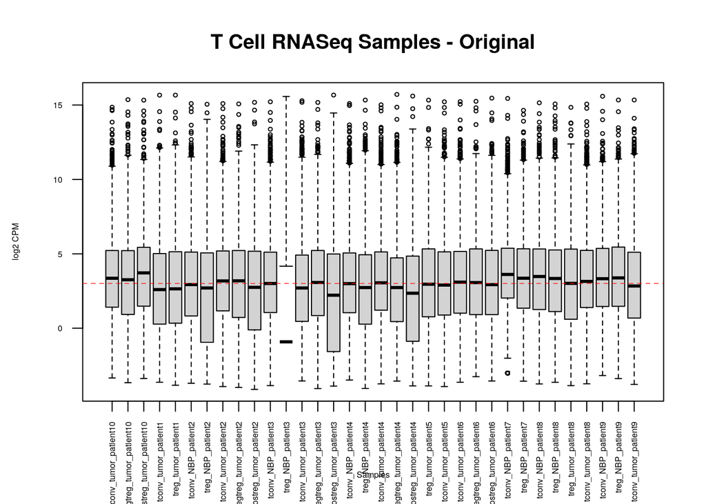

```r
original_box <- log2(cpm(original_tcell_exp[, 3:36]))
boxplot(original_box, xlab = "Samples", ylab = "log2 CPM",
        las = 2, cex = 0.5, cex.lab = 0.5, cex.axis = 0.5,
        main = "T Cell RNASeq Samples - Original")
abline(h = median(apply(original_box, 2, median)), col = "red", lwd = 0.6, lty = "dashed")
```

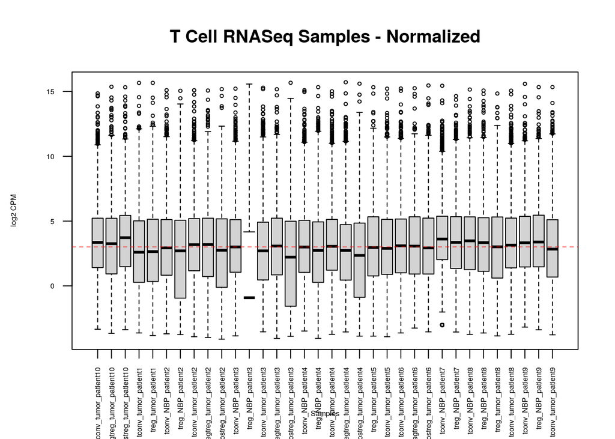

```r
normalized_box <- log2(cpm(normalized_tcell_exp[, 3:36]))
boxplot(normalized_box, xlab = "Samples", ylab = "log2 CPM", las = 2,
        cex = 0.5, cex.lab = 0.5, cex.axis = 0.5,
        main = "T Cell RNASeq Samples - Normalized")
abline(h = median(apply(normalized_box, 2, median)), col = "red", lwd = 0.6, lty = "dashed")
```

There is no significant difference between the original and normalized data set.

## 3.3 Density Plots

The density plots of the original and normalized data sets are shown below.

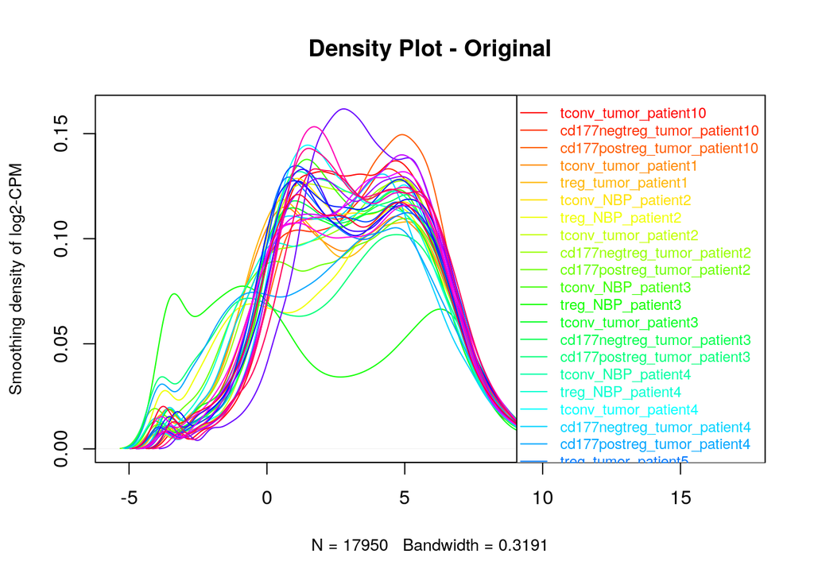

```r
original_density <- apply(log2(cpm(original_tcell_exp[, 3:36])), 2, density)

xlim1 <- 0
ylim1 <- 0

for (i in 1:length(original_density)) {
  xlim1 <- range(c(xlim1, original_density[[i]]$x))
  ylim1 <- range(c(ylim1, original_density[[i]]$y))
}

cols1 <- rainbow(length(original_density))
ltys1 <- rep(1, length(original_density))

plot(original_density[[1]], xlim = xlim1, ylim = ylim1, type = "n",
     ylab = "Smoothing density of log2-CPM",
     main = "Density Plot - Original", cex.lab = 0.85)

for (i in 1:length(original_density)) {
  lines(original_density[[i]], col = cols1[i], lty = ltys1[i])
}

legend("topright", colnames(original_box), col = cols1, lty = ltys1, cex = 0.75,
       border = "black", text.col = cols1, merge = TRUE, bg = "white")
```

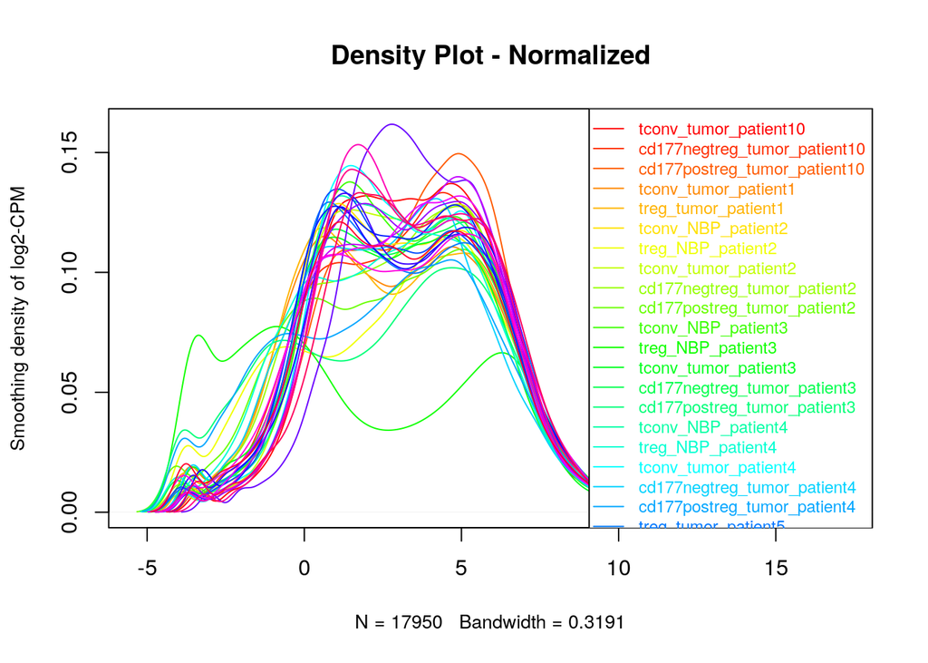

```r
normalized_density <- apply(log2(cpm(normalized_tcell_exp[, 3:36])), 2, density)

xlim2 <- 0
ylim2 <- 0

for (i in 1:length(normalized_density)) {
  xlim2 <- range(c(xlim2, normalized_density[[i]]$x))
  ylim2 <- range(c(ylim2, normalized_density[[i]]$y))
}

cols2 <- rainbow(length(normalized_density))
ltys2 <- rep(1, length(normalized_density))

plot(normalized_density[[1]], xlim = xlim2, ylim = ylim2, type = "n",
     ylab = "Smoothing density of log2-CPM",
     main = "Density Plot - Normalized", cex.lab = 0.85)

for (i in 1:length(normalized_density)) {
  lines(normalized_density[[i]], col = cols2[i], lty = ltys2[i])
}

legend("topright", colnames(normalized_box), col = cols2, lty = ltys2, cex = 0.75,
       border = "black", text.col = cols2, merge = TRUE, bg = "white")
```

## 3.4 Multidimensional Scaling (MDS) Plot

The MDS plots of the original and normalized data sets are shown below.

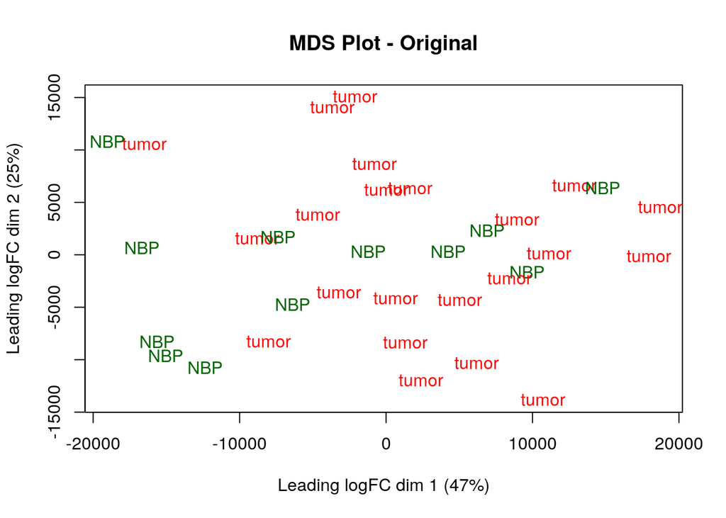

```r
limma::plotMDS(original_tcell_exp[, 3:36],
               labels = samples$tissue_type,
               col = c("darkgreen", "red")[factor(samples$tissue_type)],
               main = "MDS Plot - Original")
```

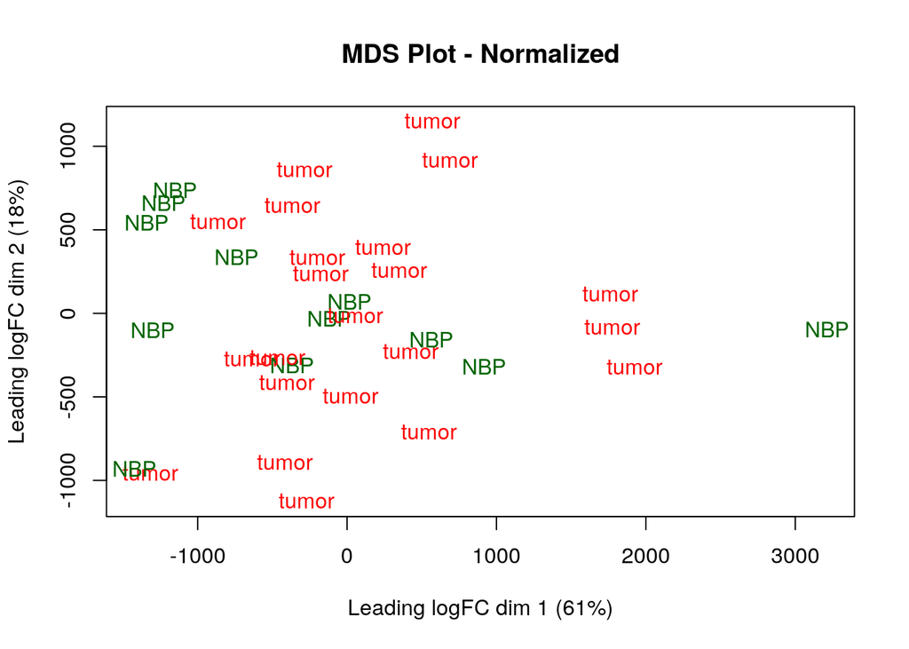

```r
limma::plotMDS(normalized_tcell_exp[, 3:36],
               labels = samples$tissue_type,
               col = c("darkgreen", "red")[factor(samples$tissue_type)],
               main = "MDS Plot - Normalized")
```

## 3.5 Dispersion

Graph the biological coefficient of variation (BCV) for genes.

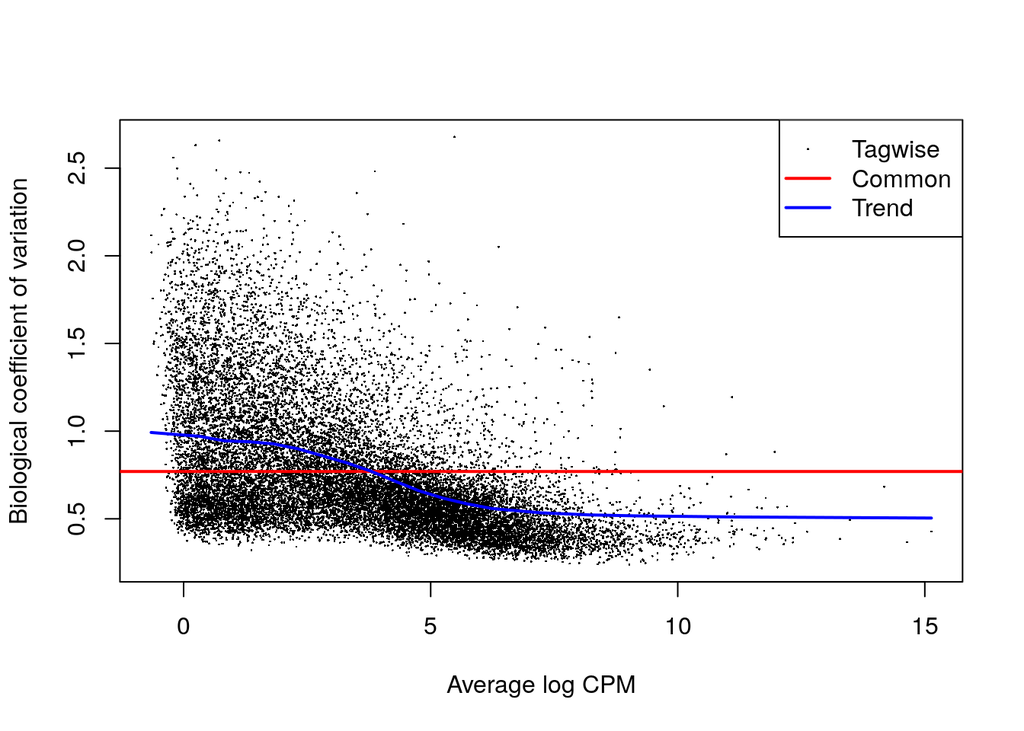

```r
model_design <- model.matrix(~samples$patients + samples$tissue_type+0)

disp <- edgeR::estimateDisp(d, model_design)
edgeR::plotBCV(disp, col.tagwise = "black", col.common = "red")
```

Create a visual representation of the mean-variance relationship.

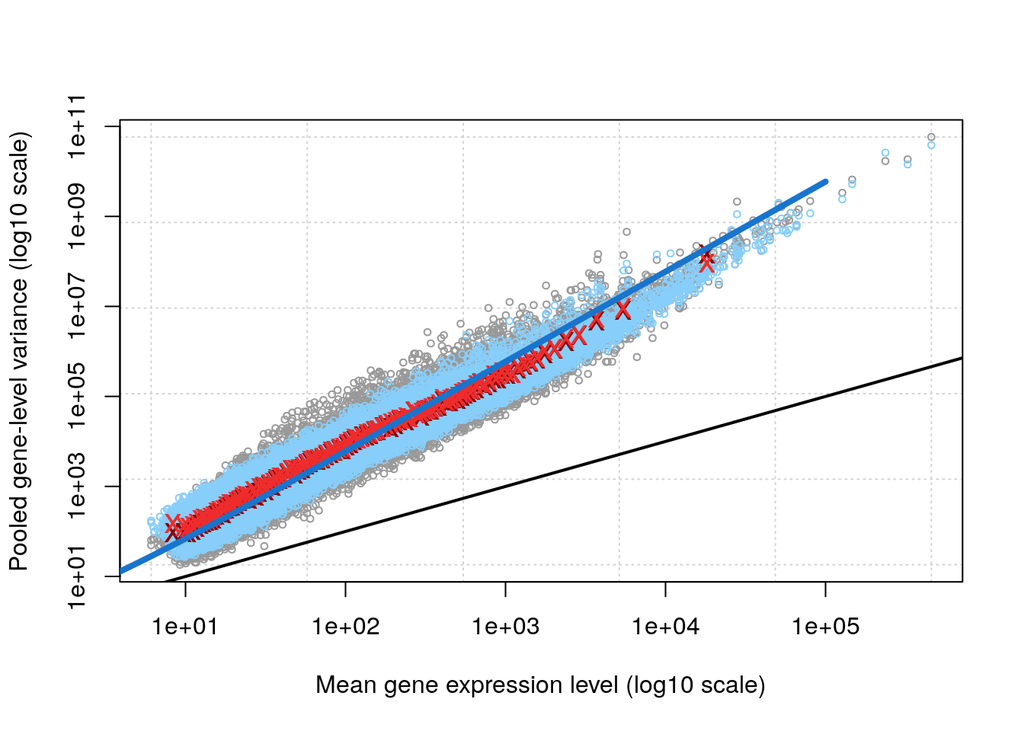

```r
edgeR::plotMeanVar(disp, show.raw.vars = TRUE,
                   show.tagwise.vars = TRUE,
                   show.ave.raw.vars = TRUE,
                   NBline = TRUE,
                   show.binned.common.disp.vars = TRUE)
```

# 4. Interpret and Document

## 4.1 Questions

### What are the control and test conditions of the dataset?

The control condition is the normal breast parenchyma (NBP) tissue, and the test condition is the tumor tissue.

### Why is the dataset of interest to you?

Breast cancer was my first genetic topic in high school and is closely related to gene mutations. This data set belongs to a published paper within ten years and contains detailed data labelling and a reasonable sample size for personal analysis.

### Were there expression values that were not unique for specific genes? How did you handle these?

I checked each Ensembl gene id’s frequency to eliminate duplicated genes. There was no duplicated gene, but I removed 5 invalid Ensembl gene ids in section *2.2 Clean the Data Set*.

### Were there expression values that could not be mapped to current HUGO symbols?

Yes, 642 (~3.6%) Ensembl gene ids could not be mapped to current HUGO symbols. I cannot check their potential HUGO symbols since the data set lacks a column for gene names. However, I decided to keep them in the data set since they might be helpful for future analysis.

### How many outliers were removed?

45,727 outliers have been removed from the data set according to edgeR protocol about low-count features. Filtering details are shown in section *2.2 Clean the Data Set*.

### What is the final coverage of your dataset?

The final coverage of the data set is 17,950 genes and 34 samples (10 patients).

## 4.2 References

Chen, Yunshun, Aaron A T Lun, and Gordon K Smyth. 2016. “From Reads to Genes to Pathways: Differential Expression Analysis of RNA-Seq Experiments Using Rsubread and the edgeR Quasi-Likelihood Pipeline.” *F1000Research* 5: 1438. https://doi.org/10.12688/f1000research.8987.2.

Chen, Yunshun, Aaron TL Lun, Davis J McCarthy, Matthew E Ritchie, Belinda Phipson, Yifang Hu, Xiaobei Zhou, Mark D Robinson, and Gordon K Smyth. 2022. *edgeR: Empirical Analysis of Digital Gene Expression Data in r*.

Davis, Sean. 2022. *GEOquery: Get Data from NCBI Gene Expression Omnibus (GEO)*.

Davis, Sean, and Paul Meltzer. 2007. “GEOquery: A Bridge Between the Gene Expression Omnibus (GEO) and BioConductor.” *Bioinformatics* 14: 1846–47.

Durinck, Steffen, and Wolfgang Huber. 2022. *biomaRt: Interface to BioMart Databases (i.e. Ensembl)*.

Durinck, Steffen, Yves Moreau, Arek Kasprzyk, Sean Davis, Bart De Moor, Alvis Brazma, and Wolfgang Huber. 2005. “BioMart and Bioconductor: A Powerful Link Between Biological Databases and Microarray Data Analysis.” *Bioinformatics* 21: 3439–40.

Durinck, Steffen, Paul T. Spellman, Ewan Birney, and Wolfgang Huber. 2009. “Mapping Identifiers for the Integration of Genomic Datasets with the r/Bioconductor Package biomaRt.” *Nature Protocols* 4: 1184–91.

Gentleman, R., V. Carey, M. Morgan, and S. Falcon. 2022. *Biobase: Base Functions for Bioconductor*. https://bioconductor.org/packages/Biobase.

Huber, W., V. J. Carey, R. Gentleman, S. Anders, M. Carlson, B. S. Carvalho, H. C. Bravo, et al. 2015a. “Orchestrating High-Throughput Genomic Analysis with Bioconductor.” *Nature Methods* 12 (2): 115–21. http://www.nature.com/nmeth/journal/v12/n2/full/nmeth.3252.html.

Huber, W., Carey, V. J., Gentleman, R., Anders, et al. 2015b. “Orchestrating High-Throughput Genomic Analysis with Bioconductor.” *Nature Methods* 12 (2): 115–21. http://www.nature.com/nmeth/journal/v12/n2/full/nmeth.3252.html.

Isserlin, Ruth. 2023a. “BCB420 Lecture 1 Notes about Docker.” https://q.utoronto.ca/courses/294979/files/24086816?module_item_id=4315655.

———. 2023b. “BCB420 Lecture 3 Notes about Expression Data.” https://q.utoronto.ca/courses/294979/files/24593564?module_item_id=4468602&fd_cookie_set=1.

———. 2023c. “BCB420 Lecture 4 Notes about Normalization.” https://q.utoronto.ca/courses/294979/files/24035536?module_item_id=4287827.

———. 2023d. “BCB420 Lecture 5 Notes about Identifier Mapping.” https://q.utoronto.ca/courses/294979/files/24035540?module_item_id=4287835.

———. 2023e. “BCB420 Lecture 7 Notes about RMarkdown.” https://q.utoronto.ca/courses/294979/files/24035549?module_item_id=4448907.

McCarthy, Davis J, Yunshun Chen, and Gordon K Smyth. 2012. “Differential Expression Analysis of Multifactor RNA-Seq Experiments with Respect to Biological Variation.” *Nucleic Acids Research* 40 (10): 4288–97. https://doi.org/10.1093/nar/gks042.

Morgan, Martin. 2022. *BiocManager: Access the Bioconductor Project Package Repository*.

Müller, Kirill, Hadley Wickham, David A. James, and Seth Falcon. 2022. *RSQLite: SQLite Interface for r*. https://CRAN.R-project.org/package=RSQLite.

Plitas, George, Catherine Konopacki, Kenmin Wu, Paula D Bos, Monica Morrow, Ekaterina V Putintseva, Dmitriy M Chudakov, and Alexander Y Rudensky. 2016. “Regulatory t Cells Exhibit Distinct Features in Human Breast Cancer.” *Immunity* 45 (5): 1122–34.

R Core Team. 2022. *R: A Language and Environment for Statistical Computing*. Vienna, Austria: R Foundation for Statistical Computing. https://www.R-project.org/.

R Special Interest Group on Databases (R-SIG-DB), Hadley Wickham, and Kirill Müller. 2022. *DBI: R Database Interface*. https://CRAN.R-project.org/package=DBI.

Ritchie, Matthew E, Belinda Phipson, Di Wu, Yifang Hu, Charity W Law, Wei Shi, and Gordon K Smyth. 2015. “limma Powers Differential Expression Analyses for RNA-Sequencing and Microarray Studies.” *Nucleic Acids Research* 43 (7): e47. https://doi.org/10.1093/nar/gkv007.

Robinson, Mark D, Davis J McCarthy, and Gordon K Smyth. 2010. “edgeR: A Bioconductor Package for Differential Expression Analysis of Digital Gene Expression Data.” *Bioinformatics* 26 (1): 139–40. https://doi.org/10.1093/bioinformatics/btp616.

Smyth, Gordon, Yifang Hu, Matthew Ritchie, Jeremy Silver, James Wettenhall, Davis McCarthy, Di Wu, et al. 2022. *Limma: Linear Models for Microarray Data*. http://bioinf.wehi.edu.au/limma.

Team, The Bioconductor Dev. 2022. *BiocGenerics: S4 Generic Functions Used in Bioconductor*. https://bioconductor.org/packages/BiocGenerics.

Xie, Yihui. 2014. “Knitr: A Comprehensive Tool for Reproducible Research in R.” In *Implementing Reproducible Computational Research*, edited by Victoria Stodden, Friedrich Leisch, and Roger D. Peng. Chapman; Hall/CRC. http://www.crcpress.com/product/isbn/9781466561595.

———. 2015. *Dynamic Documents with R and Knitr*. 2nd ed. Boca Raton, Florida: Chapman; Hall/CRC. https://yihui.org/knitr/.

———. 2022. *Knitr: A General-Purpose Package for Dynamic Report Generation in r*. https://yihui.org/knitr/.

Zhu, Hao. 2021. *kableExtra: Construct Complex Table with Kable and Pipe Syntax*. https://CRAN.R-project.org/package=kableExtra.

Zhu, Jack, and Sean Davis. 2022. *GEOmetadb: A Compilation of Metadata from NCBI GEO*.

Zhu, Yuelin, Sean Davis, Robert Stephens, Paul S. Meltzer, and Yidong Chen. 2008. “GEOmetadb: Powerful Alternative Search Engine for the Gene Expression Omnibus.” *Bioinformatics (Oxford, England)* 24 (23): 2798–2800. https://doi.org/10.1093/bioinformatics/btn520.